# coursera_eda_project2

```r
library(tidyverse)
```

## Plot 1

### Question

Have total emissions from PM<sub>2.5</sub> decreased in the United States from 1999 to 2008? Using the base plotting system, make a plot showing the total PM<sub>2.5</sub> emission from all sources for each of the years 1999, 2002, 2005, and 2008.

### Answer

```r
# please set working directory to this file's location

# download and unzip data
download.file(url = "https://d396qusza40orc.cloudfront.net/exdata%2Fdata%2FNEI_data.zip", destfile = "rawdata.zip")
unzip("rawdata.zip")

# delete the zip to clean up space
file.remove("rawdata.zip")
```

```
## [1] TRUE
```

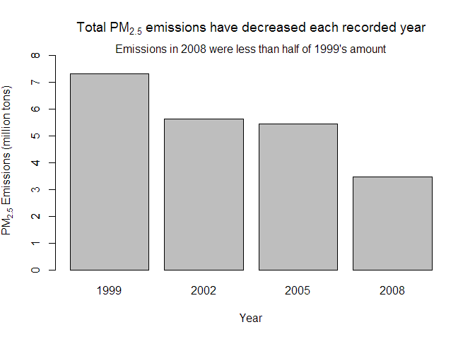

```r
# read in the data
df <- readRDS("summarySCC_PM25.rds")

# sum emissions grouped by year
dfy <- aggregate(Emissions ~ year, data = df, FUN = sum)

# simple barplot with labels
barplot(dfy$Emissions/(10^6), names.arg = dfy$year, xlab = "Year", ylab = expression("PM"[2.5]*" Emissions (million tons)"), ylim = c(0, 8),
        main = expression("Total PM"[2.5]*" emissions have decreased each recorded year"))

# specify y-axis ticks
axis(side = 2, at = seq(1, 8, by = 1))

# add subtitle
mtext("Emissions in 2008 were less than half of 1999's amount")
```

## Plot 2

### Question

Have total emissions from PM<sub>2.5</sub> decreased in the **Baltimore City, Maryland** **(fips == “24510”)** from 1999 to 2008? Use the **base** plotting system to make a plot answering this question.

### Answer

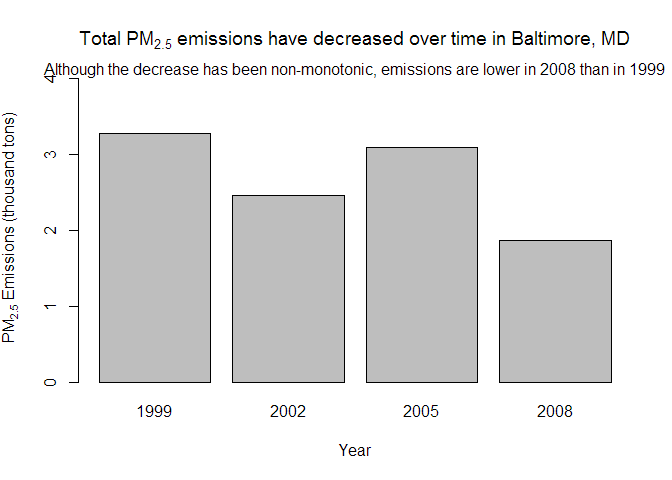

```r
# filter to Baltimore
df2 <- subset(df, fips == "24510")

# sum emissions grouped by year
dfy <- aggregate(Emissions ~ year, data = df2, FUN = sum)

# simple barplot with labels
barplot(dfy$Emissions/(10^3), names.arg = dfy$year, xlab = "Year", ylab = expression("PM"[2.5]*" Emissions (thousand tons)"), ylim = c(0, 4),
        main = expression("Total PM"[2.5]*" emissions have decreased over time in Baltimore, MD"))

# add subtitle
mtext("Although the decrease has been non-monotonic, emissions are lower in 2008 than in 1999")
```

## Plot 3

### Question

Of the four types of sources indicated by the **type** (point, nonpoint, onroad, nonroad) variable, which of these four sources have seen decreases in emissions from 1999-2008 for **Baltimore City**? Which have seen increases in emissions from 1999-2008? Use the **ggplot2** plotting system to make a plot answer this question.

### Answer

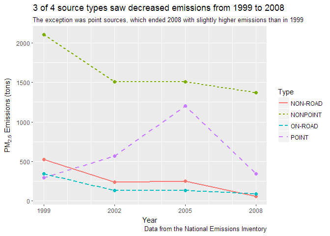

```r
# filter to Baltimore, convert to tibble for funsies
df2 <- as.tibble(subset(df, fips == "24510"))

# summarize total emissions grouped by year and type
df3 <- df2 %>%
  group_by(year, type) %>%
  summarize(Emissions = sum(Emissions, na.rm = T))

# simple line plot
df3 %>%
  ggplot(aes(year, Emissions, color = type)) +
  geom_line(size = 1, aes(linetype = type)) +
  geom_point(size = 2) +
  labs(title = "3 of 4 source types saw decreased emissions from 1999 to 2008",
       subtitle = "The exception was point sources, which ended 2008 with slightly higher emissions than in 1999",
       x = "Year",
       y = expression("PM"[2.5]*" Emissions (tons)"),
       caption = "Data from the National Emissions Inventory",
       linetype = "Type",
       color = "Type") +
  guides(color = guide_legend(override.aes = list(shape = NA))) +
  scale_x_continuous(breaks = seq(1999, 2008, by = 3),
                     minor_breaks = seq(1999, 2008, by = 1))
```

## Plot 4

### Question

Across the United States, how have emissions from coal combustion-related sources changed from 1999-2008?

### Answer

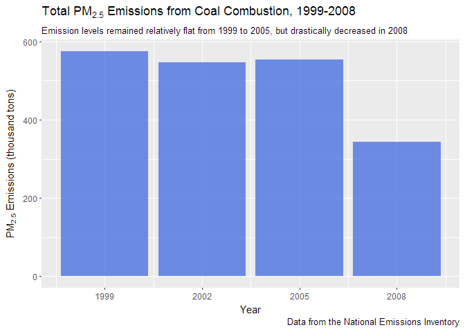

```r
scc <- readRDS("Source_Classification_Code.rds")

# merge df and scc, convert to tibble
df2 <- as.tibble(merge(df, scc, by = "SCC"))

# filter to coal combustion sources
df3 <- df2 %>%
  filter(grepl("*coal*", Short.Name, ignore.case = T) & grepl("*comb", Short.Name, ignore.case = T))

# summarize by year
df4 <- df3 %>%
  group_by(year) %>%
  summarize(Emissions = sum(Emissions, na.rm = T))

# simple bar plot
df4 %>%
  ggplot(aes(year, Emissions/1000)) +
  geom_bar(stat = "identity", fill = "royalblue", alpha = 3/4) +
  labs(title = expression("Total PM"[2.5]*" Emissions from Coal Combustion, 1999-2008"),
       subtitle = "Emission levels remained relatively flat from 1999 to 2005, but drastically decreased in 2008",
       x = "Year",
       y = expression("PM"[2.5]*" Emissions (thousand tons)"),
       caption = "Data from the National Emissions Inventory") +
  scale_x_continuous(breaks = seq(1999, 2008, by = 3))
```

## Plot 5

### Question

How have emissions from motor vehicle sources changed from 1999-2008 in **Baltimore City**?

### Answer

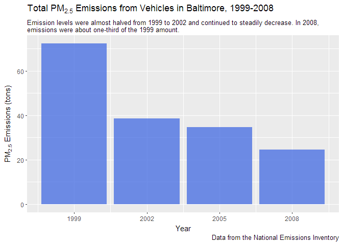

```r
# filter to motor vehicles in Baltimore
df3 <- df2 %>%
  filter(grepl("vehicle", Short.Name, ignore.case = T)) %>%
  filter(fips == "24510")

# summarize by year
df4 <- df3 %>%
  group_by(year) %>%
  summarize(Emissions = sum(Emissions, na.rm = T))

# simple bar plot
df4 %>%
  ggplot(aes(year, Emissions)) +
  geom_bar(stat = "identity", fill = "royalblue", alpha = 3/4) +
  labs(title = expression("Total PM"[2.5]*" Emissions from Vehicles in Baltimore, 1999-2008"),
       subtitle = "Emission levels were almost halved from 1999 to 2002 and continued to steadily decrease. In 2008,\nemissions were about one-third of the 1999 amount.",
       x = "Year",
       y = expression("PM"[2.5]*" Emissions (tons)"),
       caption = "Data from the National Emissions Inventory") +
  scale_x_continuous(breaks = seq(1999, 2008, by = 3))
```

## Plot 6

### Question

Compare emissions from motor vehicle sources in Baltimore City with emissions from motor vehicle sources in **Los Angeles County**, California **(fips == “06037”)**. Which city has seen greater changes over time in motor vehicle emissions?

### Answer

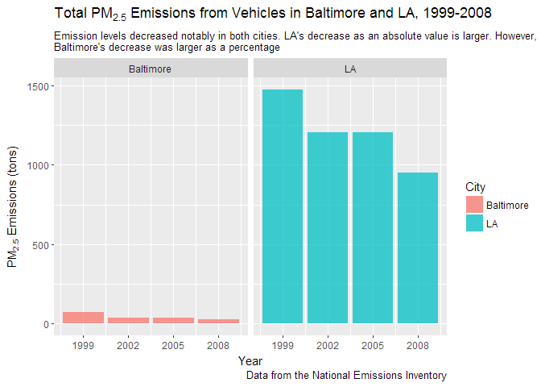

```r
# filter to motor vehicles in LA
df3_la <- df2 %>%
  filter(grepl("vehicle", Short.Name, ignore.case = T)) %>%
  filter(fips == "06037")

# summarize by year for Baltimore
df4 <- df3 %>%
  group_by(year) %>%
  summarize(Emissions = sum(Emissions, na.rm = T))

# summarize by year for LA
df4_la <- df3_la %>%
  group_by(year) %>%
  summarize(Emissions = sum(Emissions, na.rm = T))

# join the summaries for Baltimore and LA by year
df5 <- as.tibble(merge(df4, df4_la, by = "year"))

# make tidy
df6 <- df5 %>%
  rename(Baltimore = Emissions.x, LA = Emissions.y) %>%
  gather("City", "Emissions", 2:3)

# simple side by side bar plots
df6 %>%
  ggplot(aes(year, Emissions)) +
  geom_bar(stat = "identity", aes(fill = City), alpha = 3/4) +
  facet_grid(. ~ City) +
  labs(title = expression("Total PM"[2.5]*" Emissions from Vehicles in Baltimore and LA, 1999-2008"),
       subtitle = "Emission levels decreased notably in both cities. LA's decrease as an absolute value is larger. However,\nBaltimore's decrease was larger as a percentage",
       x = "Year",
       y = expression("PM"[2.5]*" Emissions (tons)"),
       caption = "Data from the National Emissions Inventory") +
  scale_x_continuous(breaks = seq(1999, 2008, by = 3))
```